# Project 2

JIAJUN LI (s2265910)

# 1 Part 1: 3D printer

## 1.1 Question 1

In this question we need to use filament1_predict function to get the probabilistic predictions of Actual_Weight and prediction intervals of two models with significance level 5%.

```r
# probabilistic predictions of Actual_Weight using model A with significance level of 5%
pda <- filament1_predict(filament1, filament1, "A", 0.05)

# probabilistic predictions of Actual_Weight using model B with significance level of 5%
pdb <- filament1_predict(filament1, filament1, "B", 0.05)
```

To inspect the predictions visually, we can plot the graph.

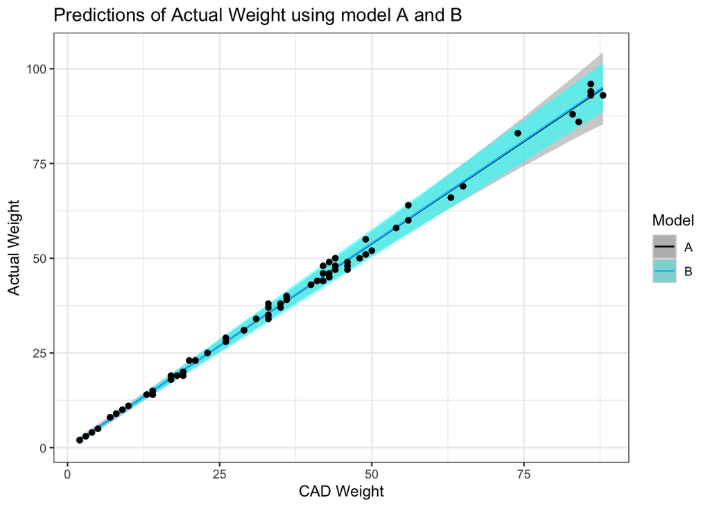

Above graph shows the probabilistic predictions of Actual Weight using two estimate model A and B, and prediction intervals of two models with significance level 5% visually. The x-axis is CAD Weights and y-axis is Actual Weight.

The black line in the graph is the prediction of Actual Weight using model A. The blue line in the graph is the prediction of Actual Weight using model B. From the graph, we can see that two prediction line are almost the same with the blue line a little bit higher than the black line, which shows that the probabilistic predicted mean values of Actual Weight using two estimate model A and B are nearly the same.

The prediction intervals of two models are both wider as the value of CAD Weight increasing. This shows standard deviation of both model increasing as the value of CAD Weight increasing meaning that the predictions for higher CAD Weight are less certain than the predictions for lower CAD Weight. However, the prediction intervals of two models with significance level 5% seems a more explicit difference as CAD Weight larger than about 65. As CAD Weight larger than about 65, the gray interval is wider than the blue interval showing that the prediction interval of model A is wider than the prediction interval of model B. This also shows that the probabilistic predicted standard deviation of model A is larger than the one of model B as CAD Weight larger than about 65.

## 1.2 Qestion 3

We use leave1out function to obtain the leave-one-out prediction means, standard deviasions, and prediction scores.

```r
# leave-one-out prediction for model A
ltA <- leave1out(filament1, "A", 0.05)
# leave-one-out prediction for model B
ltB <- leave1out(filament1, "B", 0.05)
```

The average leave-one-out scores $S(F_i, y_i)$ for each model and type of score for filament1 data is

| model | average_squared_score | average_ds_score |
| --- | --- | --- |
| A | 1.841734 | 1.128348 |
| B | 1.841995 | 0.939715 |

The average Squared Error Score measures the average of the squares of the errors. A lower score typically indicates a better fit of the model to the data. In this case, average squared error score is 1.841734 for Model A and 1.841995 for Model B. Both models have very close scores, with Model A slightly lower, implying a marginally better fit or prediction accuracy in terms of the squared metric.

The DS score is used in the context of probabilistic forecasting and evaluates the accuracy and calibration of predictive distributions. It is calculated based on the variance and the squared difference between the forecast and the actual value. Unlike typical scoring rules where a lower score is better, a lower DS score specifically indicates not just accuracy but also a more confident forecast. In this table, average DS score is 1.128348 for Model A and 0.939715 for Model B. Thus, Model B has a significantly lower DS score, indicating that it is likely making more accurate and confident probabilistic forecasts than Model A.

While Model A performs slightly better on the average squared score (which could reflect a lower mean squared error), Model B is substantially better in terms of the average Dawid-Sebastiani score, suggesting that Model B’s probabilistic forecasts are more accurate and confident. Assessing which prediction model is better is unclear as it depends on what attributes of the prediction distribution are important.

## 1.3 Question 4

In this section we need to construct a Monte Carlo estimate of the p-value to test the exchangeability between model predictions from A and B against the alternative hypothesis that B is better than A.

Here, we use test statistic $\frac{1}{N} \sum_{i=1}^N (S_i^A - S_i^B)$. For this particular test statistic, we can first compute the pairwise score differences and then generate randomisation samples by sampling random sign changes. Then, we can compute the test statistic for each randomly altered set of values and compare with the original test statistic.

The p-value is the probability that under the null hypothesis, we would observe a test statistic as extreme as or more extreme than the observed statistic. A low p-value (typically < 0.05) would lead us to reject the null hypothesis in favor of the alternative, suggesting that model B is indeed better.

We can do the approach above by

```r
# score difference of two model
score_diff <- data.frame(se = ltA$score_lt_se - ltB$score_lt_se,
                         ds = ltA$score_lt_ds - ltB$score_lt_ds)

# test statistic
statistic0 <- score_diff %>% summarise(se = mean(se), ds = mean(ds))

# number of iterations
J <- 10000

# initialize the statistic data frame
statistic <- data.frame(se = numeric(J), ds = numeric(J))

# loop J times
for(loop in seq_len(J)) {
  # generate randomisation samples by sampling random sign changes
  random_sign <- sample(c(-1,1), size = nrow(score_diff), replace = TRUE)
  statistic[loop,] <- score_diff %>% summarise(se = mean(random_sign * se),
                                               ds = mean(random_sign * ds))
}

# Compute the test statistic for each randomly altered set of values and compare with the original test statistic
p_values <-
  statistic %>%
  summarise(se = mean (se > statistic0$se),
            ds = mean (ds > statistic0$ds))
```

Then, we get the p-value for squared error and dawid-sebastiani scores, which is

| se | ds |
| --- | --- |
| 0.4989 | 0.0436 |

The p-values for the squared error and Dawid-Sebastiani score, estimated using Monte Carlo simulations, are approximately 0.4989 and 0.0436, respectively.

For squared error scores, it is 0.4989. With this p-value, we cannot reject the null hypothesis of exchangeability. There isn’t strong evidence to suggest that model B is better than model A based on the p-value of squared error scores. This result also means that we cannot reject the null hypothesis of exchangeability with respect to accuracy of two model.

For DS scores, the p-value is 0.0436, which is smaller than 0.05 showing that we need to reject the null hypothesis of exchangeability. In DS score, we take predictive variance into consideration instead of just the squared error. This results shows that Model B’s probabilistic forecasts are more accurate and confident.

Monte Carlo Standard Errors are a measure used to assess the precision of estimates obtained through Monte Carlo simulations.The smaller the MCSE, the more reliable the estimate is considered to be. In this approach, the Monte Carlo standard errors is

| se | ds |
| --- | --- |
| 0.005 | 0.002042 |

From the table, we can see that the Monte Carlo standard errors are 0.005 and 0.002042 for squared error and ds scores respectively. Thus, two standard errors are very small showing that the estimate is considered to be reliable.

# 2 Part 2: Archaeology in the Baltic sea

The results of running estimate(y=c(237,256), xi=1/1001, a=0.5, b=0.5, K=10000) is

| p_hat | EN | Ephi |
| --- | --- | --- |
| 7.9e-06 | 981.9492 | 0.3741221 |

Here, the function estimate that takes inputs y, xi, a, b, and K and implements the Monte Carlo integration method in Q2 to approximate $p_y (y), E(N|y)$, and $E(\phi|y)$. In the above example, we use y= (237, 256) showing that the number of left femur is 237 and the number of right femur is 256. Here, in the example, $\xi$ is $\frac{1}{1001}$, which means the expectation of the prior distribution $Geom(\xi)$ is 1000. This is based on our simple model that the archaeologist believed that around 1000 individuals were buried. The a and b are both 0.5, which is the prior distribution of finding the femur with given number of total number of people buried. The a and b have same value showing that they would find around half on the femurs in the model. In statistic methodology, we know that the low value of a and b has little effect in shaping the posterior, so our model will base on the sampling.

The value of approximate $p_y (y)$ is about $7.921036 \cdot e^{-6}$, which is very small. This could represent the estimated marginal likelihood of observing the data $p_y (y)$, which is a probability measure. The small value suggests that, under the model and priors chosen, the observed data are quite unlikely. This could be due to a model that does not fit well or very informative priors that do not match the data well.

The value of $E(N|y)$ is 981.9492, which is the Monte Carlo estimate of the posterior expectation of the total number of people buried $E(N|y)$. This estimate is lower than the 1000 individuals initially believed by the archaeologist to be buried, but it’s in the same ballpark. It suggests that, based on the model and the data (the counts of left and right femurs), there might be slightly fewer individuals buried than previously thought.

The value of $E(\phi|y)$ is approximately 0.3741221, which is the Monte Carlo estimate of the posterior expectation of the probability of finding a femur $E(\phi|y)$. Given that the prior belief was that this probability would be close to 1/2, the estimated value is somewhat lower. This could indicate that the probability of finding a femur is less than what was expected prior to the analysis. It could reflect issues such as incomplete recovery of remains or other site-specific factors that reduced the likelihood of finding femurs.

In summary, the results seem to suggest that the actual number of individuals buried might be slightly lower than expected, and the probability of finding a femur is also lower than the anticipated 50%. Furthermore, this simple model might be improved by adding more additional data affecting the model or finding alternative models.

# 3 Code appendix

```r
#' JIAJUN LI, s2265910
#' Add your own function definitions on this file.

#' neg_log_lik
#
#' @description Evaluate the negated log-likelihood for model A and B
#' @param beta A vector with the beta parameters
#' @param data A `data.frame` with the same variables as the `filament1` data set.
#' Must have columns `CAD_Weight` and `Actual_Weight`
#' @param model Either "A" for a log-linear variance model, or "B" for a proportional
#' scaling error model

neg_log_lik <- function(beta, data, model){

  mu <- beta[1] + beta[2]*data[["CAD_Weight"]]

  # distinguish between the two models to find the particular standard deviation for the betas
  if(model == "A") {
    sigma <- sqrt(exp(beta[3] + beta[4]*data[["CAD_Weight"]]))
  }else{
    sigma <- sqrt(exp(beta[3])+exp(beta[4]) * (data[["CAD_Weight"]]^2))
  }
  - sum(dnorm(data[["Actual_Weight"]],
              mean = mu,
              sd=sigma,
              log = TRUE))

}

#' filament_estimate
#
#' @description Estimate filament models with different variance structure
#' @param data A `data.frame` with the same variables as the `filament1` data set.
#' Must have columns `CAD_Weight` and `Actual_Weight`
#' @param model Either "A" for a log-linear variance model, or "B" for a proportional
#' scaling error model
#' @return An estimation object suitable for use with [filament1_predict()]

filament1_estimate <- function(data, model) {
  model <- match.arg(model, c("A", "B"))
  if (model == "A") {
    beta_start <- c(-0.1, 1.07, -2, 0.05)
  } else {
    beta_start <- c(-0.15, 1.07, -13.5, -6.5)
  }
  opt <- optim(beta_start,
               neg_log_lik,
               data = data,
               model = model,
               hessian = TRUE,
               method = "Nelder-Mead",
               control = list(maxit = 5000)
  )
  fit <- list(
    model = model,
    par = opt$par,
    hessian = opt$hessian
  )
  class(fit) <- c("filament1_estimate", "list")
  fit
}

#' filament1_aux_EV
#'
#' @description Evaluate the expectation and variance for model A and B
#' @param beta A vector with the beta parameters
#' @param data A `data.frame` containing the required predictors, including `CAD_Weight`
#' @param model Either "A" for a log-linear variance model, or "B" for a proportional
#' scaling error model
#' @param Sigma_beta : If not NULL, an estimate of the covariance matrix for
#                 the uncertainty of estimated betas
#' @return A list with four elements:
#     E : E(y|beta,x)
#     V : Var(y|beta,x)
#     VE : Var(E(y|beta,x)|x) or NULL
#     EV : E(Var(y|beta,x)|x) or NULL

filament1_aux_EV <- function(beta, data, model = c("A", "B"),
                             Sigma_beta = NULL) {

  model <- match.arg(model)
  if (model == "A") {

    ZE.0 <- model.matrix( ~ 1 + CAD_Weight, data = data)
    ZV.0 <- model.matrix( ~ 1 + CAD_Weight, data = data)
    ZE = cbind(ZE.0, ZV.0 * 0)
    ZV = cbind(ZE.0 * 0, ZV.0)

    VE <- EV <- NULL
    if (!is.null(Sigma_beta)) {
      # E(Var(y|beta,x)|x)
      EV <- exp(ZV %*% beta + rowSums(ZV * (ZV %*% Sigma_beta)) / 2)
      # Var(E(y|beta,x)|x)
      VE <- rowSums(ZE * (ZE %*% Sigma_beta))
    }
    out <- list(
      E = ZE %*% beta,
      V = exp(ZV %*% beta),
      VE = VE,
      EV = EV
    )
  } else {

    ZE.0 <- model.matrix( ~ 1 + CAD_Weight, data = data)
    ZV.0 <- model.matrix( ~ 1 + I(CAD_Weight^2), data = data)
    ZE = cbind(ZE.0, ZV.0 * 0)
    ZV = cbind(ZE.0 * 0, ZV.0)

    VE <- EV <- NULL
    if (!is.null(Sigma_beta)) {
      # E(Var(y|beta,x)|x)
      # (pmin: Ignore large Sigma_beta values)
      EV <- ZV %*% exp(beta + pmin(0.5^2, diag(Sigma_beta)) / 2)
      # Var(E(y|beta,x)|x)
      VE <- rowSums(ZE * (ZE %*% Sigma_beta))
    }
    out <- list(
      E = ZE %*% beta,
      V = ZV %*% exp(beta),
      VE = VE,
      EV = EV
    )
  }
  out
}

#' filament1_predict
#
#' @description The summary of predictive distribution for each row of
#' `newdata` set based on the given `data` set
#' @param data A `data.frame` with the same variables as the `filament1` data set.
#'  Must have columns `CAD_Weight` and `Actual_Weight`.
#' @param newdata the data set used to predict
#' @param model Either "A" for a log-linear variance model, or "B" for a proportional
#' scaling error model
#' @param level significant level for prediction intervals
#' @return a data frame with variables mean,sd,lwr and upr summarizing
#' predictive distribution for each row of `newdata`.
filament1_predict <- function(data, newdata, model, level){
  # use build in function to estimate the given data
  estimate <- filament1_estimate(data, model)
  # based on the estimate to get the prediction of newdata
  aux_EV <- filament1_aux_EV(estimate$par, newdata, model, solve(estimate$hessian))
  mean <- aux_EV$E
  # get the standard deviation of predictive distribution
  sd <- sqrt(aux_EV$VE + aux_EV$EV)
  lwr <- mean - qt(1 - level/2, df = nrow(data) -2)*sd
  upr <- mean + qt(1 - level/2, df = nrow(data) -2)*sd
  # return the data frame
  tibble(mean, sd, lwr, upr)
}

#' squared_error
#'
#' @description The function used to compute squared error scores
#' @param pred_dis predictive distribution of the data set with model
#' @param testdata actual value to compute squared error score
#' @return the squared error score
squared_error <- function(pred_dis, testdata){
  (testdata$Actual_Weight - pred_dis$mean)^2
}

#' ds_error
#'
#' @description The function used to compute Dawid-Sebastiani error scores
#' @param pred_dis predictive distribution of the data set with model
#' @param testdata actual value to compute squared error score
#' @return the Dawid-Sebastiani error score
ds_error <- function(pred_dis, testdata){
  (testdata$Actual_Weight - pred_dis$mean)^2/(pred_dis$sd^2)+log(pred_dis$sd^2)
}

#' leave1out
#'
#' @description performs leave-one-out cross-validation for the selected model
#' for each observation
#' @param data A `data.frame` with the same variables as the `filament1` data set.
#' @param model Either "A" for a log-linear variance model, or "B" for a proportional
#' @param level significant level for prediction intervals
#' @return a dataframe with original data and four additional columns
#' mean, sd, se and ds of leave-one-out prediction means, standard deviations,
#' and prediction scores.
leave1out <- function(data ,model, level){
  # initialize 4 columns
  lt_mean <- numeric(nrow(data))
  lt_sd <- numeric(nrow(data))
  score_lt_se <- numeric(nrow(data))
  score_lt_ds <- numeric(nrow(data))
  # loop all rows of the dataframe
  for (i in seq_len(nrow(data))){
    # use the other rows to predict
    pred <- filament1_predict(data = data%>% filter(Index != i),
                              newdata = data%>%filter(Index == i),
                              model = model , level = level)
    # use the specific row to treat as test data
    obs <- data %>%  filter(Index == i)
    lt_mean[i] <- pred$mean
    lt_sd[i] <- pred$sd
    # calculate two scores
    score_lt_se[i] <- squared_error(pred, obs)
    score_lt_ds[i] <- ds_error(pred, obs)
  }
  data_frame(data, lt_mean, lt_sd, score_lt_se, score_lt_ds)
}

#' arch_loglike
#'
#' @description evaluates the combined log-likelihood log[p(y|N, φ)] for a collection
#' y of y-observations
#' @param y a collection y of y-observations
#' @param dataf a data frame with columns `N` and `phi`
#' @return a data frame with the log-likelihood for each row-pair (N, phi)
arch_loglike <- function(y, dataf){
  # get the value of left femur
  y1 <- y[1]
  # get the value of right femur
  y2 <- y[2]
  # initialize the log likelihood column
  arch_log <- numeric(nrow(dataf))
  for (i in seq_len(nrow(dataf))){
    # the combined log-likelihood function
    arch_log[i] <- -lgamma(y1+1) - lgamma(y2+1) -lgamma(dataf$N[i]-y1+1)-
      lgamma(dataf$N[i] - y2 +1) + 2*lgamma(dataf$N[i] +1) +
      (y1 + y2)*log(dataf$phi[i]) + (2*dataf$N[i] - y1 -y2)*log(1-dataf$phi[i])
  }
  data_frame(dataf, arch_log)
}


#' estimate
#'
#' @description takes inputs y, xi, a, b, and K and implements the Monte Carlo
#' integration method in question2 to approximate py (y), E(N|y), and E(φ|y).
#' @param y a collection y of y-observations
#' @param xi the prior with Geometric distribution Geom(xi)
#' @param a the prior distribution with Beta(a,b)
#' @param b the prior distribution with Beta(a,b)
#' @param K the number of iteration of Monte Carlo
#' @return the approximate p (y), E(N|y), and E(φ|y) by the Monte Carlo
#' integration method in question2

estimate <- function(y, xi, a, b, K){
  # random set the value of N by its distribution
  N <- rgeom(n = K, prob = xi)
  # random set the value of phi by its distribution
  phi <- rbeta(K, a, b)
  # get the dataframe of row-pair (N, phi)
  data <- data_frame(N, phi)
  # use build function to get the data frame of log-likelihood for each row-pair (N, phi)
  log_p_data <- arch_loglike(y, data)
  # get the log-likelihood for each row-pair (N, phi)
  log_p <- log_p_data$arch_log
  # get the likelihood for each row-pair (N, phi)
  p <- exp(log_p)
  # Monte Carlo estimate p (y)
  p_hat <- sum(p)/K
  # Monte Carlo estimate E(N|y)
  EN <- 1/(p_hat*K) * sum(log_p_data$N * p)
  # Monte Carlo estimate E(φ|y)
  Ephi <- 1/(p_hat*K) * sum(log_p_data$phi * p)
  data_frame(p_hat, EN, Ephi)
}
```